# test log-transformation

Victor Møller Poulsen

# data

```r
d <- read_csv("/work/50114/MAG/data/modeling/psych_replication_matched.csv") %>%
  mutate(log_teamsize = log(n_authors),
         condition_coded = ifelse(condition == "experiment", 1, 0),
         condition_fct = as_factor(condition),
         teamsize_scaled = (n_authors-min(n_authors))/(max(n_authors)-min(n_authors)),
         days_after_2010_scaled = days_after_2010/max(days_after_2010),
         teamsize_log = log(n_authors),
         id_match = as_factor(match_group),
         id_fct = as_factor(PaperId)) %>% # because min = 0
  glimpse()
```

```
## Rows: 744
## Columns: 14
## $ match_group            <dbl> 1, 1, 2, 2, 3, 3, 4, 5, 6, 7, 7, 8, 8, 9, 9, 10…
## $ condition              <chr> "experiment", "control", "experiment", "control…
## $ n_authors              <dbl> 5, 5, 1, 1, 11, 11, 2, 2, 2, 4, 4, 4, 4, 6, 6, …
## $ PaperId                <dbl> 2134174525, 1490919247, 2395494269, 2007726610,…
## $ days_after_2010        <dbl> 0, 0, 0, 0, 0, 0, 0, 0, 0, 0, 0, 3, 3, 31, 31, …
## $ c_5                    <dbl> 0, 0, 0, 0, 10, 0, 6, 0, 6, 2, 133, 0, 28, 65, …
## $ log_teamsize           <dbl> 1.6094379, 1.6094379, 0.0000000, 0.0000000, 2.3…
## $ condition_coded        <dbl> 1, 0, 1, 0, 1, 0, 1, 1, 1, 0, 1, 0, 1, 1, 0, 1,…
## $ condition_fct          <fct> experiment, control, experiment, control, exper…
## $ teamsize_scaled        <dbl> 0.08, 0.08, 0.00, 0.00, 0.20, 0.20, 0.02, 0.02,…
## $ days_after_2010_scaled <dbl> 0.000000000, 0.000000000, 0.000000000, 0.000000…
## $ teamsize_log           <dbl> 1.6094379, 1.6094379, 0.0000000, 0.0000000, 2.3…
## $ id_match               <fct> 1, 1, 2, 2, 3, 3, 4, 5, 6, 7, 7, 8, 8, 9, 9, 10…
## $ id_fct                 <fct> 2134174525, 1490919247, 2395494269, 2007726610,…
```

# model formulae

same model-specifications as test_interactions2. just differs by being log of teamsize rather than 0-1 scaling.

```r
f_logteam_0 <- bf(c_5 ~ 0 + condition_fct + condition_fct:teamsize_log + (1|id_match))
f_logteam_1 <- bf(c_5 ~ 1 + condition_fct + condition_fct:teamsize_log + (1|id_match))
f_logteam_01 <- bf(c_5 ~ 0 + Intercept + condition_fct + condition_fct:teamsize_log + (1|id_match))
```

Just doing negbinomial() for now, since we had Rhat issues for both negative binomial and zero-inflated negative binomial (does not seem to be the main cause of issues).

f_team_0: b, sd, shape f_team_1: b, Intercept, sd, shape f_team_01: b, sd, shape (Intercept becomes b).

set priors

```r
# negbin baseline
negbin_0 <- c(prior(gamma(0.01, 0.01), class = shape),
              prior(normal(0, 1), class = b),
              prior(normal(0, 1), class = sd)) # a wild guess

# zinegbin baseline
negbin_1 = c(prior(gamma(0.01, 0.01), class = shape),
             prior(normal(0, 1), class = b),
             prior(normal(0, 1), class = Intercept),
             prior(normal(0, 1), class = sd)) # a wild guess

# can be used for all interactions (without thinking)
negbin_01 <- c(prior(gamma(0.01, 0.01), class = shape),
              prior(normal(0, 1), class = b),
              prior(normal(0, 1), class = sd)) # a wild guess
```

# sample prior only

# check priors

```r
prior_check <- function(model, ndraws, title, xmax){

  pp_check(model,
           ndraws = ndraws) +
    labs(title = title) +
    theme_minimal() +
    xlim(0, xmax)

}
```

```r
prior_check(negbin_prior_log_0, 100, "No Intercept (x cutoff: 25)", 25)
```

```
## Warning: Removed 101 rows containing non-finite values (stat_density).
```

[figure not shown]

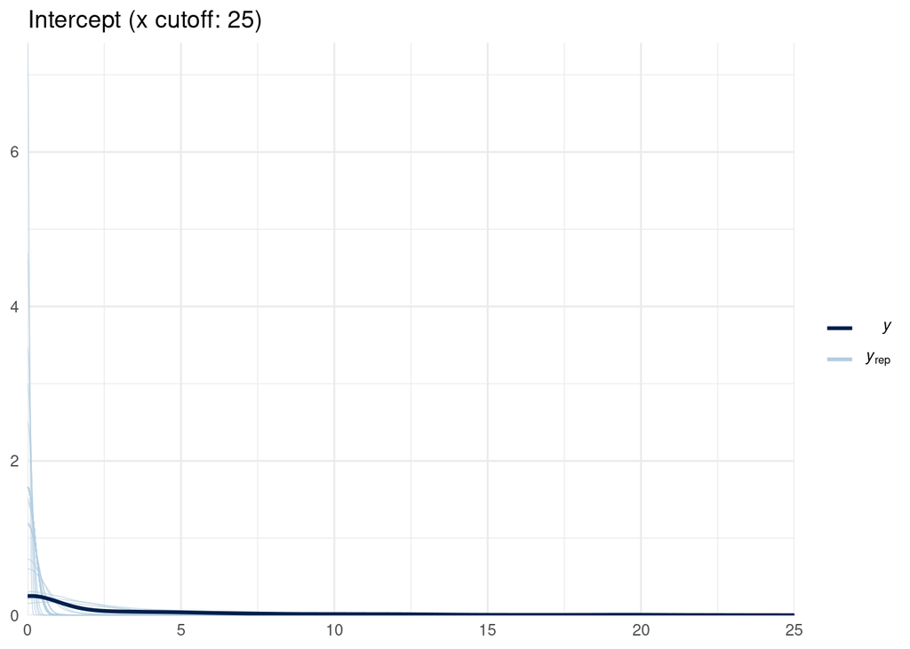

```r
prior_check(negbin_prior_log_1, 100, "Intercept (x cutoff: 25)", 25)
```

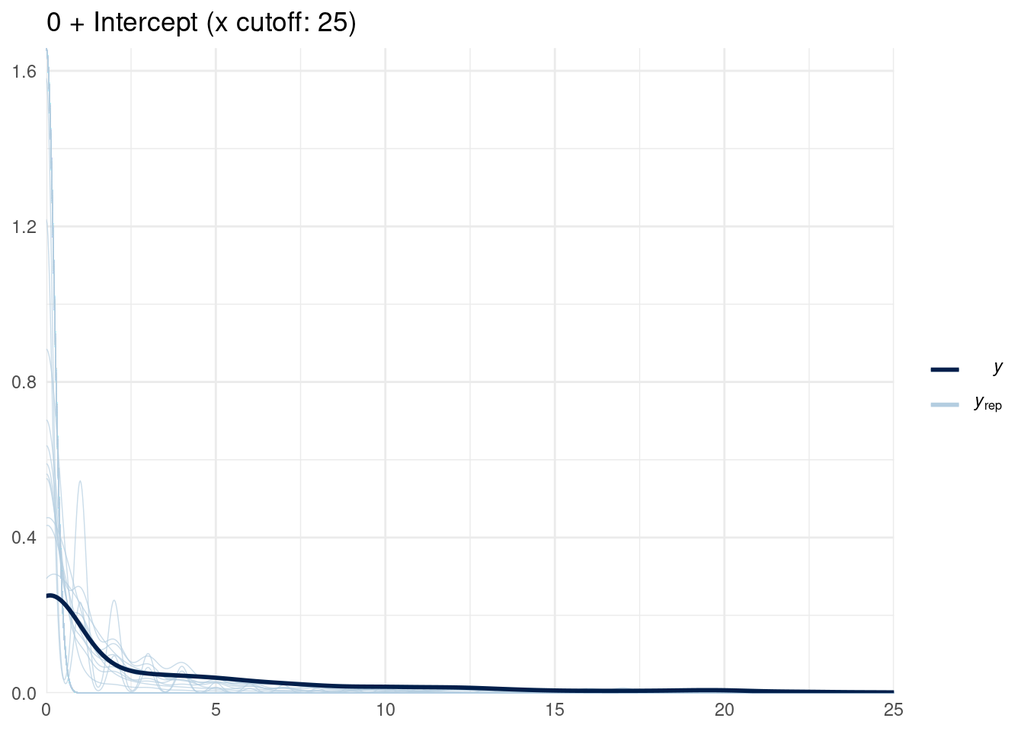

```r
prior_check(negbin_prior_log_01, 100, "0 + Intercept (x cutoff: 25)", 25)
```

# fit models

```r
## baseline
negbin_post_log_0 <- fit_model(
  family = negbinomial(),
  formula = f_logteam_0,
  prior = negbin_0,
  sample_prior = TRUE,
  file = "/work/50114/MAG/modeling/models/negbin_post_log_0"
)

## baseline
negbin_post_log_1 <- fit_model(
  family = negbinomial(),
  formula = f_logteam_1,
  prior = negbin_1,
  sample_prior = TRUE,
  file = "/work/50114/MAG/modeling/models/negbin_post_log_1"
)

## baseline
negbin_post_log_01 <- fit_model(
  family = negbinomial(),
  formula = f_logteam_01,
  prior = negbin_01,
  sample_prior = TRUE,
  file = "/work/50114/MAG/modeling/models/negbin_post_log_01"
)
```

# check traces

looks ok.

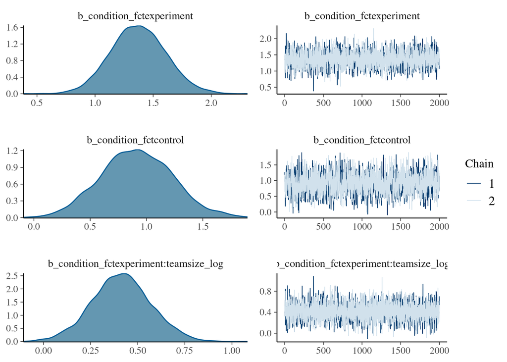

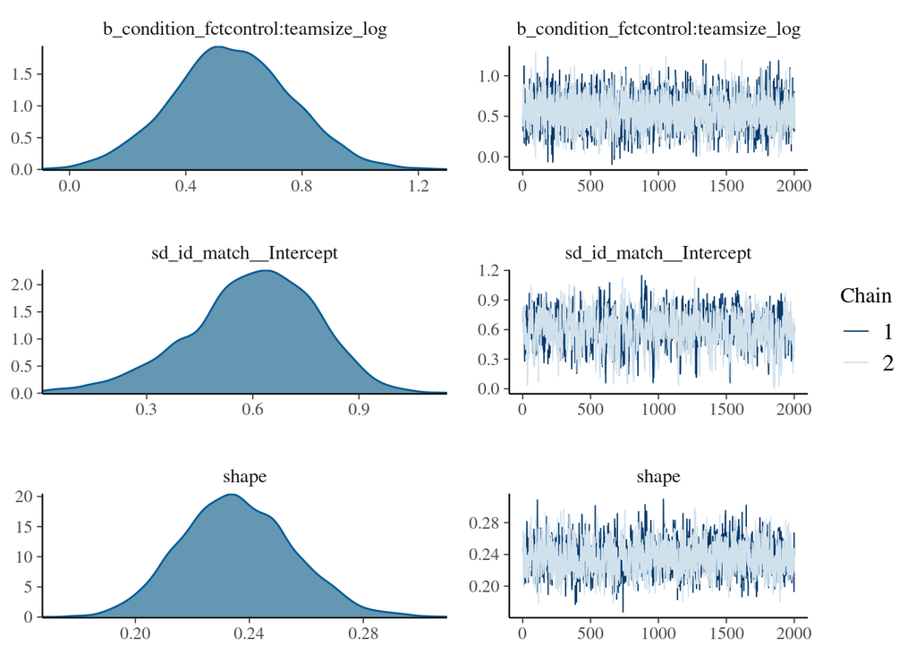

```r
# some auto-correlation
# effect almost entirely in random effect
plot(negbin_post_log_0, N = 3)
```

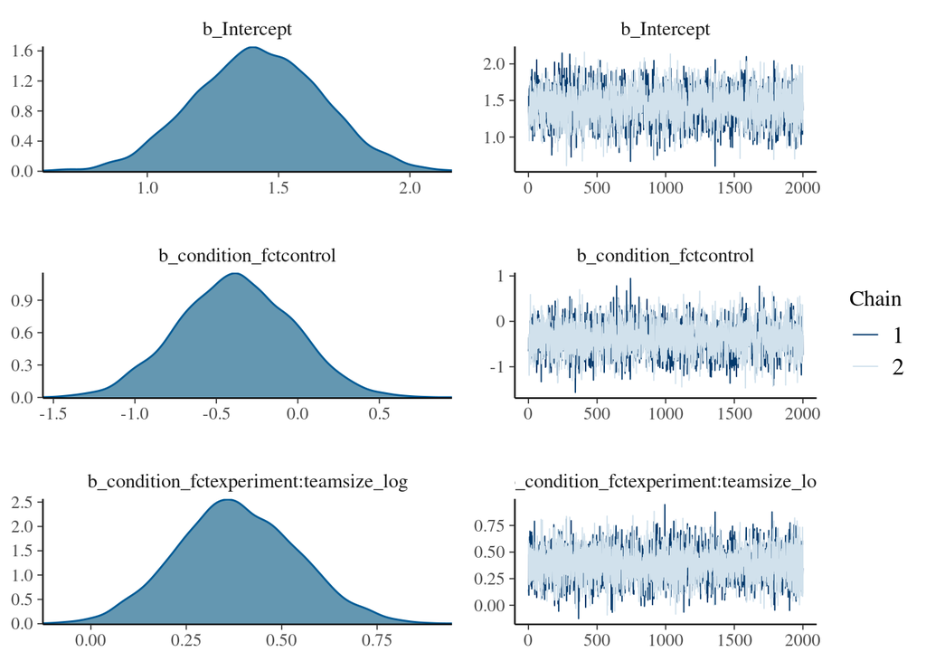

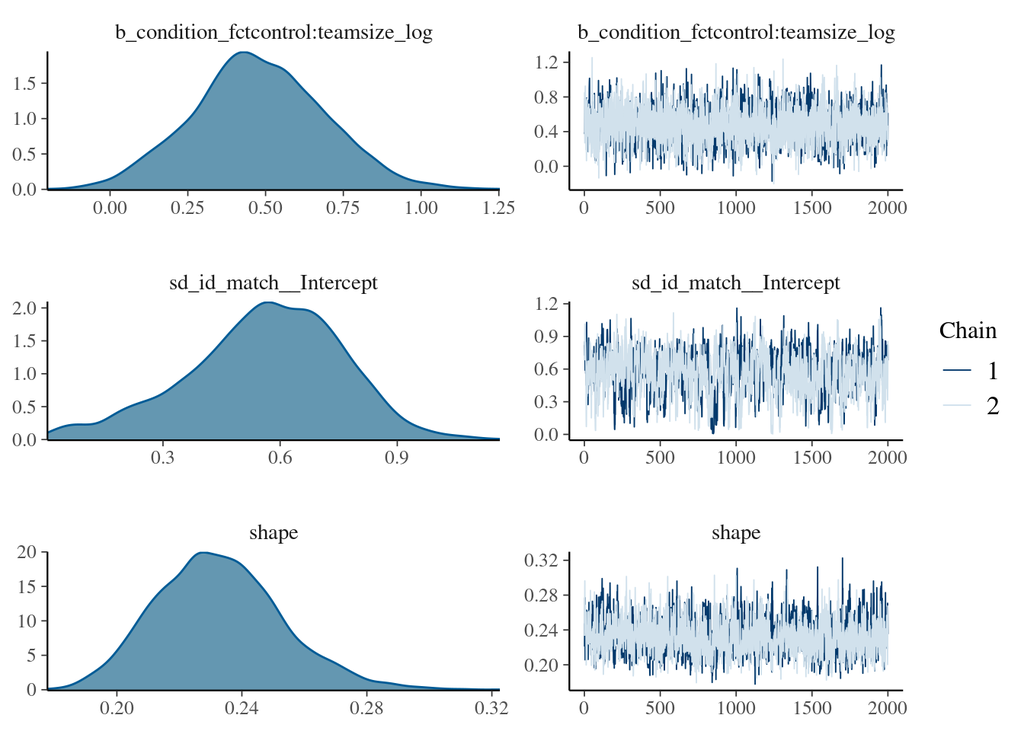

```r
# some auto-correlation
# effect almost entirely in random effect
plot(negbin_post_log_1, N = 3)
```

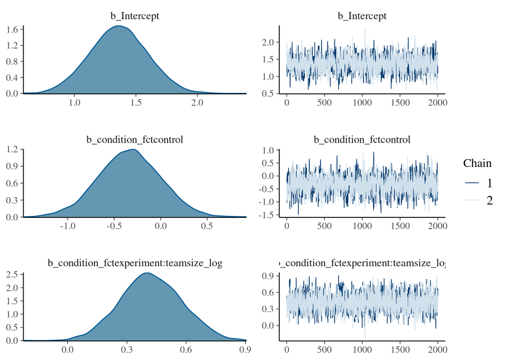

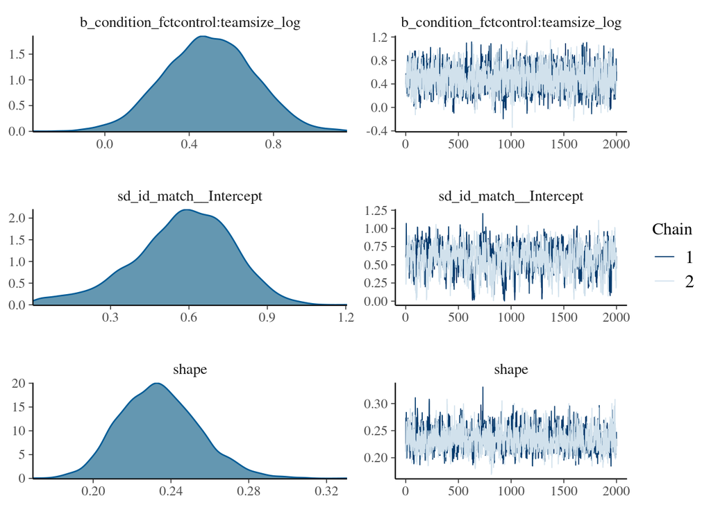

```r
# same issues
plot(negbin_post_log_01, N = 3)
```